# Unicorn Startups - EDA

## Unicorn Startups EDA

#### Import relevant packages

```python
import pandas as pd
import numpy as np
from datetime import datetime
import matplotlib.pyplot as plt
import seaborn as sns

%matplotlib inline

plt.rcParams['figure.figsize'] = [12,6]
plt.rcParams['figure.dpi'] = 70
sns.set_theme(style='white')
sns.set_palette(palette='Spectral')
```

#### Load the data

```python
unicorn = pd.read_csv('Unicorn_Clean.csv')
```

```python
unicorn.head()
```

|  | Unnamed: 0 | Company | Valuation ($B) | Date Joined | Country | City | Industry | Investor 1 | Investor 2 | Investor 3 | Investor 4 |
| --- | --- | --- | --- | --- | --- | --- | --- | --- | --- | --- | --- |
| 0 | 0 | Bytedance | 140.0 | 2017-04-07 | China | Beijing | Artificial intelligence | Sequoia Capital China | SIG Asia Investments | Sina Weibo | Softbank Group |
| 1 | 1 | SpaceX | 100.3 | 2012-12-01 | United States | Hawthorne | Other | Founders Fund | Draper Fisher Jurvetson | Rothenberg Ventures | NaN |
| 2 | 2 | Stripe | 95.0 | 2014-01-23 | United States | San Francisco | Fintech | Khosla Ventures | LowercaseCapital | capitalG | NaN |
| 3 | 3 | Klarna | 45.6 | 2011-12-12 | Sweden | Stockholm | Fintech | Institutional Venture Partners | Sequoia Capital | General Atlantic | NaN |
| 4 | 4 | Canva | 40.0 | 2018-01-08 | Australia | Surry Hills | Internet software & services | Sequoia Capital China | Blackbird Ventures | Matrix Partners | NaN |

```python
unicorn.info()
```

```
<class 'pandas.core.frame.DataFrame'>
RangeIndex: 936 entries, 0 to 935
Data columns (total 11 columns):
 #   Column          Non-Null Count  Dtype
---  ------          --------------  -----
 0   Unnamed: 0      936 non-null    int64
 1   Company         936 non-null    object
 2   Valuation ($B)  936 non-null    float64
 3   Date Joined     936 non-null    object
 4   Country         936 non-null    object
 5   City            936 non-null    object
 6   Industry        936 non-null    object
 7   Investor 1      936 non-null    object
 8   Investor 2      890 non-null    object
 9   Investor 3      806 non-null    object
 10  Investor 4      7 non-null      object
dtypes: float64(1), int64(1), object(9)
memory usage: 80.6+ KB
```

```python
unicorn = unicorn.drop('Unnamed: 0',axis=1)
unicorn.info()
```

```
<class 'pandas.core.frame.DataFrame'>
RangeIndex: 936 entries, 0 to 935
Data columns (total 10 columns):
 #   Column          Non-Null Count  Dtype
---  ------          --------------  -----
 0   Company         936 non-null    object
 1   Valuation ($B)  936 non-null    float64
 2   Date Joined     936 non-null    object
 3   Country         936 non-null    object
 4   City            936 non-null    object
 5   Industry        936 non-null    object
 6   Investor 1      936 non-null    object
 7   Investor 2      890 non-null    object
 8   Investor 3      806 non-null    object
 9   Investor 4      7 non-null      object
dtypes: float64(1), object(9)
memory usage: 73.2+ KB
```

```python
unicorn['Date Joined'] = pd.to_datetime(unicorn['Date Joined'])
unicorn.info()
```

```
<class 'pandas.core.frame.DataFrame'>
RangeIndex: 936 entries, 0 to 935
Data columns (total 10 columns):
 #   Column          Non-Null Count  Dtype
---  ------          --------------  -----
 0   Company         936 non-null    object
 1   Valuation ($B)  936 non-null    float64
 2   Date Joined     936 non-null    datetime64[ns]
 3   Country         936 non-null    object
 4   City            936 non-null    object
 5   Industry        936 non-null    object
 6   Investor 1      936 non-null    object
 7   Investor 2      890 non-null    object
 8   Investor 3      806 non-null    object
 9   Investor 4      7 non-null      object
dtypes: datetime64[ns](1), float64(1), object(8)
memory usage: 73.2+ KB
```

#### Questions to answer:

1. Top 20 companies with the largest valuations
2. Top 10 countries with the most number of unicorn startups
3. Countries with the highest total valuation of unicorns.
4. Top countries with highest average valuation of unicorns.
5. Top industries with most startups
6. Top industries with the highest total valuation of unicorns.
7. Top investors with most startups
8. Number of startups per year.
9. Startups per industry per year.
10. Startups per country per year.

#### 1. Top 20 companies with the largest valuations.

```python
#Number of companies in the dataset
unicorn['Company'].nunique()
```

```
935
```

There are 936 entries in the dateset but only 935 unique entries for 'Company'. Let's check if there are null values in this column.

```python
unicorn['Company'].isnull().sum()
```

```
0
```

There are no null values in the columns. Let's check for duplicate values.

```python
unicorn[unicorn['Company'].duplicated()]
```

|  | Company | Valuation ($B) | Date Joined | Country | City | Industry | Investor 1 | Investor 2 | Investor 3 | Investor 4 |
| --- | --- | --- | --- | --- | --- | --- | --- | --- | --- | --- |
| 141 | Bolt | 4.75 | 2018-05-29 | Estonia | Tallinn | Auto & transportation | Didi Chuxing | Diamler | TMT Investments | NaN |

Company 'Bolt' is duplicated in the column. Let's retrieve the entries and see if all of their information in other columns are exactly the same

```python
unicorn[unicorn['Company']=='Bolt']
```

|  | Company | Valuation ($B) | Date Joined | Country | City | Industry | Investor 1 | Investor 2 | Investor 3 | Investor 4 |
| --- | --- | --- | --- | --- | --- | --- | --- | --- | --- | --- |
| 94 | Bolt | 6.00 | 2021-10-08 | United States | San Francisco | Fintech | Activant Capital | Tribe Capital | General Atlantic | NaN |
| 141 | Bolt | 4.75 | 2018-05-29 | Estonia | Tallinn | Auto & transportation | Didi Chuxing | Diamler | TMT Investments | NaN |

The the information in the other columns are not the same. They come from different countries, United States and Estonia. Therefore we can keep them both in the dataset since they are two different companies that just have the same name.

```python
top_val = unicorn.sort_values(by='Valuation ($B)', ascending=False).head(20)
top_val
```

|  | Company | Valuation ($B) | Date Joined | Country | City | Industry | Investor 1 | Investor 2 | Investor 3 | Investor 4 |
| --- | --- | --- | --- | --- | --- | --- | --- | --- | --- | --- |
| 0 | Bytedance | 140.0 | 2017-04-07 | China | Beijing | Artificial intelligence | Sequoia Capital China | SIG Asia Investments | Sina Weibo | Softbank Group |
| 1 | SpaceX | 100.3 | 2012-12-01 | United States | Hawthorne | Other | Founders Fund | Draper Fisher Jurvetson | Rothenberg Ventures | NaN |
| 2 | Stripe | 95.0 | 2014-01-23 | United States | San Francisco | Fintech | Khosla Ventures | LowercaseCapital | capitalG | NaN |
| 3 | Klarna | 45.6 | 2011-12-12 | Sweden | Stockholm | Fintech | Institutional Venture Partners | Sequoia Capital | General Atlantic | NaN |
| 4 | Canva | 40.0 | 2018-01-08 | Australia | Surry Hills | Internet software & services | Sequoia Capital China | Blackbird Ventures | Matrix Partners | NaN |
| 5 | Instacart | 39.0 | 2014-12-30 | United States | San Francisco | Supply chain logistics & delivery | Khosla Ventures | Kleiner Perkins Caufield & Byers | Collaborative Fund | NaN |
| 6 | Databricks | 38.0 | 2019-02-05 | United States | San Francisco | Data management & analytics | Andreessen Horowitz | New Enterprise Associates | Battery Ventures | NaN |
| 7 | Revolut | 33.0 | 2018-04-26 | United Kingdom | London | Fintech | index Ventures | DST Global | Ribbit Capital | NaN |
| 8 | Nubank | 30.0 | 2018-03-01 | Brazil | Sao Paulo | Fintech | Sequoia Capital | Redpoint e.ventures | Kaszek Ventures | NaN |
| 9 | Epic Games | 28.7 | 2018-10-26 | United States | Cary | Other | Tencent Holdings | KKR | Smash Ventures | NaN |
| 10 | Chime | 25.0 | 2019-03-05 | United States | San Francisco | Fintech | Forerunner Ventures | Crosslink Capital | Homebrew | NaN |
| 11 | FTX | 25.0 | 2021-07-20 | Hong Kong | Hong Kong | Fintech | Sequoia Capital | Thoma Bravo | Softbank | NaN |
| 12 | BYJU's | 21.0 | 2017-07-25 | India | Bengaluru | Edtech | Tencent Holdings | Lightspeed India Partners | Sequoia Capital India | NaN |
| 13 | Xiaohongshu | 20.0 | 2016-03-31 | China | Shanghai | E-commerce & direct-to-consumer | GGV Capital | ZhenFund | Tencent | NaN |
| 14 | J&T Express | 20.0 | 2021-04-07 | Indonesia | Jakarta | Supply chain logistics & delivery | Hillhouse Capital Management | Boyu Capital | Sequoia Capital China | NaN |
| 15 | Fanatics | 18.0 | 2012-06-06 | United States | Jacksonville | E-commerce & direct-to-consumer | SoftBank Group | Andreessen Horowitz | Temasek Holdings | NaN |
| 16 | Yuanfudao | 15.5 | 2017-05-31 | China | Beijing | Edtech | Tencent Holdings | Warbug Pincus | IDG Capital | NaN |
| 19 | Checkout.com | 15.0 | 2019-05-02 | United Kingdom | London | Fintech | Tiger Global Management | Insight Partners | DST Global | NaN |
| 20 | goPuff | 15.0 | 2020-10-08 | United States | Philadelphia | E-commerce & direct-to-consumer | Accel | Softbank Group | Anthos Capital | NaN |
| 18 | SHEIN | 15.0 | 2018-07-03 | China | Shenzhen | E-commerce & direct-to-consumer | Tiger Global Management | Sequoia Capital China | Shunwei Capital Partners | NaN |

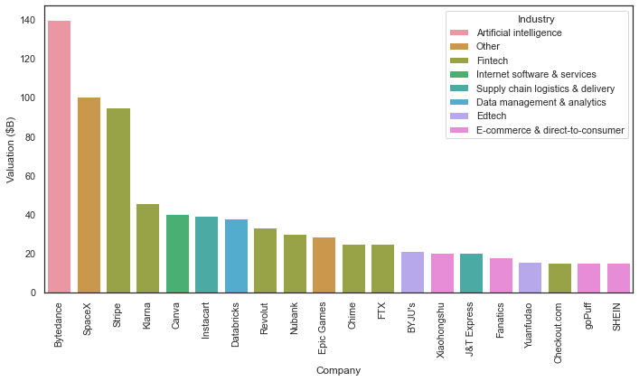

```python
g1 = sns.barplot(data=top_val, x = 'Company', y = 'Valuation ($B)', hue = 'Industry', dodge = False)
g1.set_xticklabels(g1.get_xticklabels(), rotation=90);
```

#### 2. Top 10 countries with the most number of unicorn startups.

Check the number of countries included in the dataset.

```python
unicorn['Country'].nunique()
```

```
45
```

```python
unicorn['Country'].value_counts()
```

```
United States           478
China                   169
India                    51
United Kingdom           37
Germany                  23
Israel                   21
France                   19
Brazil                   15
Canada                   15
Singapore                11
South Korea              11
Hong Kong                 7
Japan                     6
Australia                 6
Indonesia                 5
Netherlands               5
Mexico                    5
Spain                     4
Switzerland               4
Sweden                    4
United Arab Emirates      3
Ireland                   3
Norway                    3
Denmark                   2
Thailand                  2
Turkey                    2
Belgium                   2
Colombia                  2
Philippines               2
South Africa              2
Austria                   2
Finland                   2
Nigeria                   1
Luxembourg                1
Senegal                   1
Malaysia                  1
Estonia                   1
Lithuania                 1
Vietnam                   1
Czech Republic            1
Santa Clara               1
Argentina                 1
Croatia                   1
Chile                     1
Bermuda                   1
Name: Country, dtype: int64
```

```python
countries_most_unicorns = unicorn.groupby(by='Country').count().sort_values(by='Company',ascending=False).head(10)
```

```
[Text(0, 0, 'United States'),
```

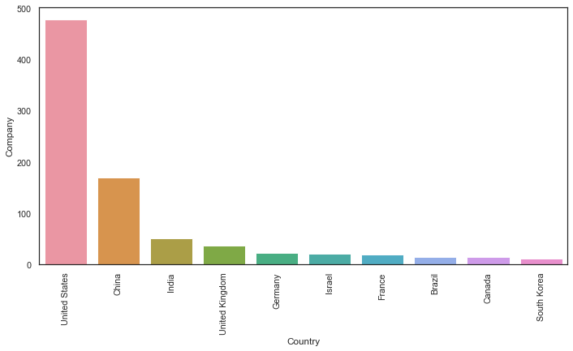

```python
g2 = sns.barplot(data=countries_most_unicorns, x = countries_most_unicorns.index, y = 'Company')
g2.set_xticklabels(g2.get_xticklabels(), rotation=90)
```

#### 3. Countries with the highest total valuation of unicorns.

```python
countries_total_val_unicorns = unicorn.groupby(by='Country').sum().sort_values(by='Valuation ($B)', ascending = False).head(10)
countries_total_val_unicorns
```

| Country | Valuation ($B) |
| --- | --- |
| United States | 1605.03 |
| China | 569.48 |
| United Kingdom | 150.29 |
| India | 148.45 |
| Germany | 66.63 |
| Brazil | 61.05 |
| Sweden | 58.08 |
| Australia | 50.60 |
| Israel | 43.82 |
| Hong Kong | 41.45 |

```
[Text(0, 0, 'United States'),
```

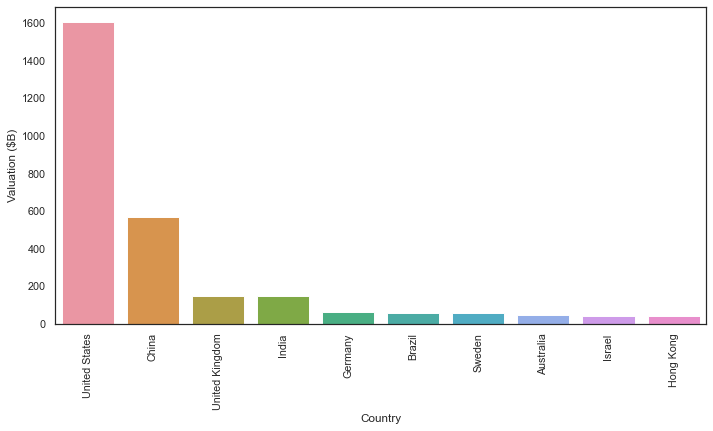

```python
g3 = sns.barplot(data=countries_total_val_unicorns, x=countries_total_val_unicorns.index, y='Valuation ($B)')
g3.set_xticklabels(g3.get_xticklabels(),rotation=90)
```

#### 4. Top countries with highest average valuation of unicorns.

```python
countries_ave_val_unicorn = unicorn.groupby('Country').mean().sort_values(by='Valuation ($B)', ascending = False).head(10)
```

```
[Text(0, 0, 'Sweden'),
```

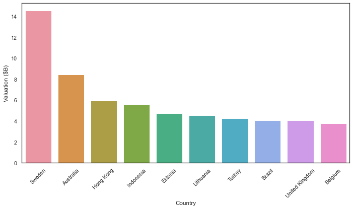

```python
g4 = sns.barplot(data=countries_ave_val_unicorn, x=countries_ave_val_unicorn.index, y='Valuation ($B)')
g4.set_xticklabels(g4.get_xticklabels(), rotation=45)
```

```python
unicorn.groupby('Country').mean().sort_values(by='Valuation ($B)', ascending = False)
```

| Country | Valuation ($B) |
| --- | --- |
| Sweden | 14.520000 |
| Australia | 8.433333 |
| Hong Kong | 5.921429 |
| Indonesia | 5.580000 |
| Estonia | 4.750000 |
| Lithuania | 4.530000 |
| Turkey | 4.250000 |
| Brazil | 4.070000 |
| United Kingdom | 4.061892 |
| Belgium | 3.775000 |
| China | 3.369704 |
| United States | 3.357803 |
| Colombia | 3.200000 |
| Mexico | 3.040000 |
| Vietnam | 3.000000 |
| India | 2.910784 |
| Austria | 2.905000 |
| Germany | 2.896957 |
| Netherlands | 2.860000 |
| Canada | 2.515333 |
| Argentina | 2.450000 |
| South Korea | 2.244545 |
| Israel | 2.086667 |
| Ireland | 2.066667 |
| Luxembourg | 2.000000 |
| Nigeria | 2.000000 |
| Santa Clara | 2.000000 |
| France | 1.874211 |
| Senegal | 1.700000 |
| Bermuda | 1.600000 |
| Finland | 1.500000 |
| Chile | 1.500000 |
| United Arab Emirates | 1.500000 |
| Philippines | 1.500000 |
| Spain | 1.487500 |
| Japan | 1.470000 |
| Switzerland | 1.400000 |
| Singapore | 1.354545 |
| Denmark | 1.350000 |
| Malaysia | 1.300000 |
| South Africa | 1.295000 |
| Norway | 1.266667 |
| Thailand | 1.250000 |
| Czech Republic | 1.200000 |
| Croatia | 1.000000 |

#### 5. Top industries with most startups.

```python
#Check the number of industries included in the dataset.
unicorn['Industry'].nunique()
```

```
15
```

```python
industries_most_startups = unicorn.groupby('Industry').count().sort_values(by='Company', ascending=False)
industries_most_startups
```

| Industry | Company | Valuation ($B) | Date Joined | Country | City | Investor 1 | Investor 2 | Investor 3 | Investor 4 |
| --- | --- | --- | --- | --- | --- | --- | --- | --- | --- |
| Fintech | 191 | 191 | 191 | 191 | 191 | 191 | 183 | 173 | 0 |
| Internet software & services | 167 | 167 | 167 | 167 | 167 | 167 | 162 | 149 | 0 |
| E-commerce & direct-to-consumer | 102 | 102 | 102 | 102 | 102 | 102 | 98 | 89 | 0 |
| Artificial intelligence | 73 | 73 | 73 | 73 | 73 | 73 | 68 | 62 | 3 |
| Health | 63 | 63 | 63 | 63 | 63 | 63 | 61 | 53 | 0 |
| Other | 51 | 51 | 51 | 51 | 51 | 51 | 41 | 33 | 0 |
| Supply chain logistics & delivery | 51 | 51 | 51 | 51 | 51 | 51 | 49 | 46 | 2 |
| Cybersecurity | 41 | 41 | 41 | 41 | 41 | 41 | 41 | 40 | 0 |
| Mobile & telecommunications | 37 | 37 | 37 | 37 | 37 | 37 | 32 | 26 | 2 |
| Data management & analytics | 36 | 36 | 36 | 36 | 36 | 36 | 36 | 33 | 0 |
| Hardware | 32 | 32 | 32 | 32 | 32 | 32 | 32 | 26 | 0 |
| Auto & transportation | 29 | 29 | 29 | 29 | 29 | 29 | 28 | 24 | 0 |
| Edtech | 27 | 27 | 27 | 27 | 27 | 27 | 26 | 26 | 0 |
| Consumer & retail | 23 | 23 | 23 | 23 | 23 | 23 | 20 | 15 | 0 |
| Travel | 13 | 13 | 13 | 13 | 13 | 13 | 13 | 11 | 0 |

```
[Text(0, 0, 'Fintech'),
```

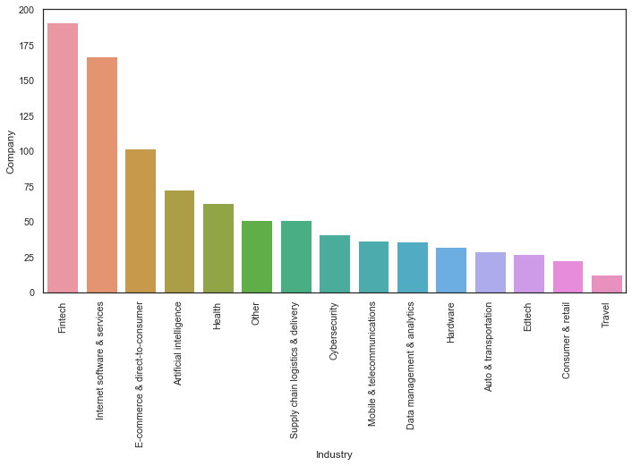

```python
g5 = sns.barplot(data=industries_most_startups, x=industries_most_startups.index, y='Company')
g5.set_xticklabels(g5.get_xticklabels(), rotation=90)
```

#### 6. Top industries with the highest total valuation of unicorns.

```python
top_inds_highest_total_val = unicorn.groupby('Industry').sum().sort_values(by='Valuation ($B)', ascending=False)
top_inds_highest_total_val
```

| Industry | Valuation ($B) |
| --- | --- |
| Fintech | 744.13 |
| Internet software & services | 483.76 |
| Artificial intelligence | 312.84 |
| E-commerce & direct-to-consumer | 291.10 |
| Other | 245.46 |
| Health | 166.26 |
| Supply chain logistics & delivery | 146.29 |
| Data management & analytics | 121.70 |
| Cybersecurity | 107.54 |
| Hardware | 98.59 |
| Auto & transportation | 89.30 |
| Edtech | 85.37 |
| Mobile & telecommunications | 79.09 |
| Consumer & retail | 64.13 |
| Travel | 35.60 |

```
[Text(0, 0, 'Fintech'),
```

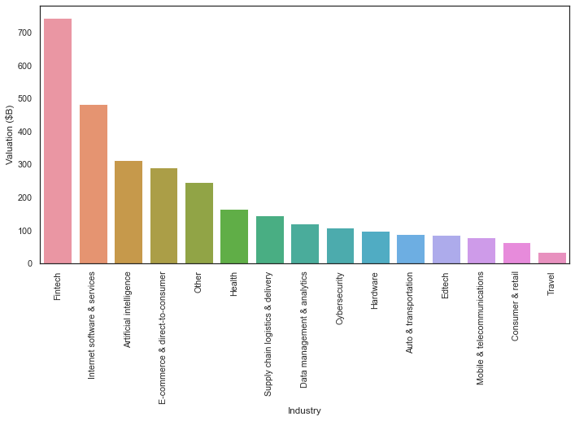

```python
g6 = sns.barplot(data=top_inds_highest_total_val, x=top_inds_highest_total_val.index, y='Valuation ($B)')
g6.set_xticklabels(g6.get_xticklabels(), rotation=90)
```

#### 7. Top investors invested with most number of startups

```python
investors = unicorn.iloc[:, -4:-1].values.T.ravel()
investors
```

```
array(['Sequoia Capital China', 'Founders Fund', 'Khosla Ventures', ...,
       'Silversmith Capital Partners', 'Ten Eleven Ventures',
       'TDM Growth Partners'], dtype=object)
```

```python
investors = pd.Series(investors)
```

Count the number of investors

```python
investors.count()
```

```
2632
```

Count the number of unique investors

```python
investors.nunique()
```

```
1140
```

Count the number of occurence of each unique investor

```python
investors.value_counts()
```

```
Accel                      49
Sequoia Capital China      47
Tiger Global Management    42
Sequoia Capital            40
Insight Partners           39
                           ..
A91 Partners                1
Bitmain Technologies        1
Spar Capital                1
Lightrock                   1
Promus Ventures             1
Length: 1140, dtype: int64
```

Make a list of the top 20 investors in terms of number of unicorn startups they are invested in.

```python
top_investor_num_unicorns = investors.value_counts().head(20)
top_investor_num_unicorns
```

```
Accel                               49
Sequoia Capital China               47
Tiger Global Management             42
Sequoia Capital                     40
Insight Partners                    39
Andreessen Horowitz                 39
SoftBank Group                      29
Index Ventures                      28
Lightspeed Venture Partners         27
General Catalyst                    27
General Atlantic                    26
Tencent Holdings                    25
Google Ventures                     24
IDG Capital                         23
Sequoia Capital India               21
New Enterprise Associates           21
DST Global                          20
Kleiner Perkins Caufield & Byers    20
Bessemer Venture Partners           18
Khosla Ventures                     18
dtype: int64
```

```python
top_investor_num_unicorns = pd.DataFrame(top_investor_num_unicorns)
```

```python
top_investor_num_unicorns.rename(columns={0:"Number of unicorn startups"},inplace=True)
top_investor_num_unicorns
```

|  | Number of unicorn startups |
| --- | --- |
| Accel | 49 |
| Sequoia Capital China | 47 |
| Tiger Global Management | 42 |
| Sequoia Capital | 40 |
| Insight Partners | 39 |
| Andreessen Horowitz | 39 |
| SoftBank Group | 29 |
| Index Ventures | 28 |
| Lightspeed Venture Partners | 27 |
| General Catalyst | 27 |
| General Atlantic | 26 |
| Tencent Holdings | 25 |
| Google Ventures | 24 |
| IDG Capital | 23 |
| Sequoia Capital India | 21 |
| New Enterprise Associates | 21 |
| DST Global | 20 |
| Kleiner Perkins Caufield & Byers | 20 |
| Bessemer Venture Partners | 18 |
| Khosla Ventures | 18 |

```
[Text(0, 0, 'Accel'),
```

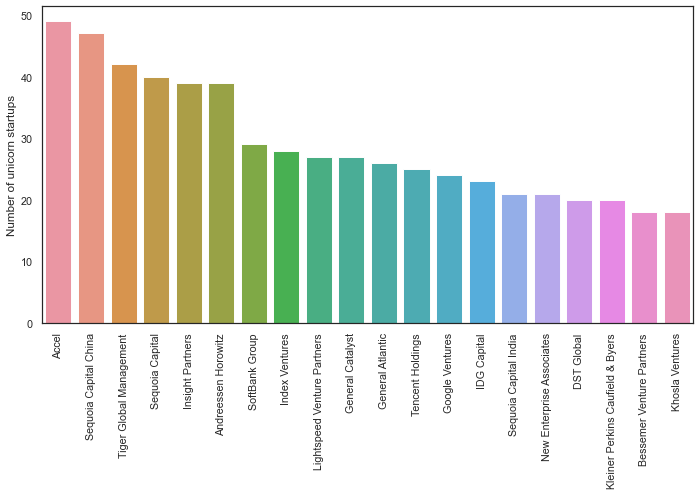

```python
g7 = sns.barplot(data=top_investor_num_unicorns, x=top_investor_num_unicorns.index, y='Number of unicorn startups')
g7.set_xticklabels(g7.get_xticklabels(),rotation=90)
```

#### 8. Number of startups per year.

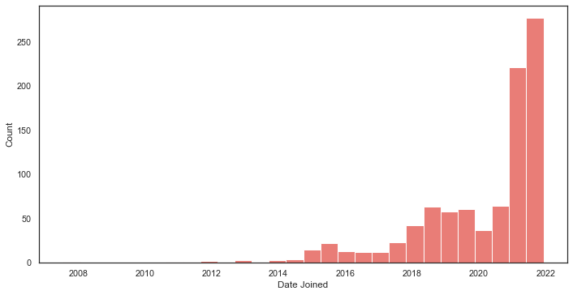

```python
g8 = sns.histplot(data=unicorn, x='Date Joined')
```

#### 9. Startups per industry per year.

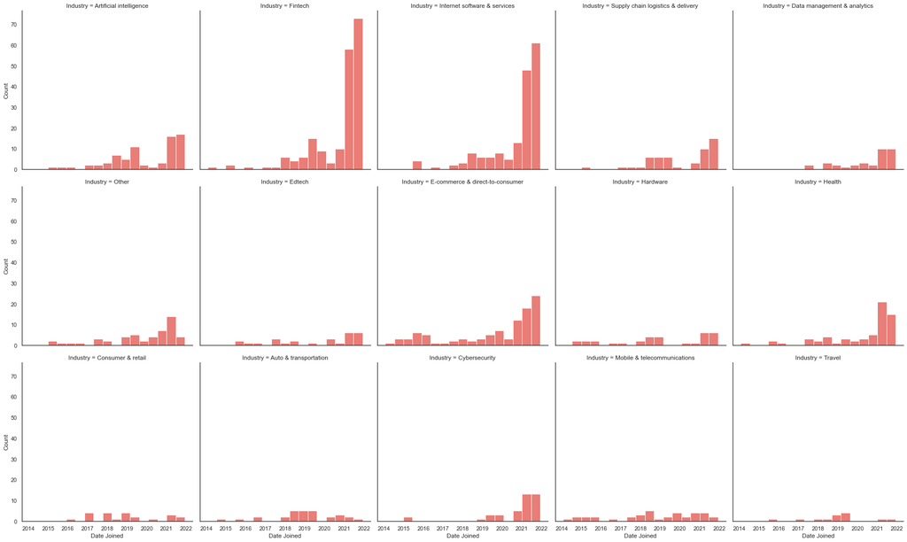

```python
unicorn_2015 = unicorn[unicorn['Date Joined']> '2014']
g9 = sns.displot(data=unicorn_2015, x='Date Joined',col="Industry",col_wrap=5)
```

#### 10. Startups per country per year. (Only the top 10 countries with the most number of startups)

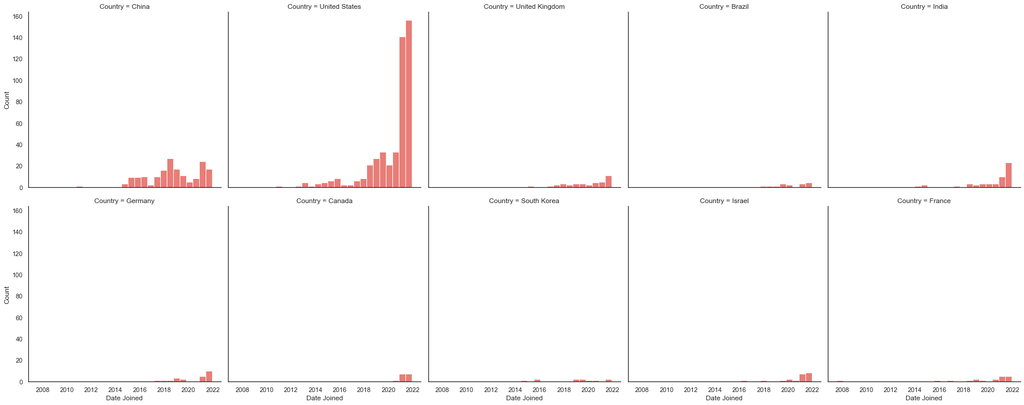

```python
g10 = sns.displot(data=unicorn[unicorn['Country'].isin(countries_most_unicorns.index)], x='Date Joined',col="Country",col_wrap=5)
```